# Seminar 2

SOK-2011

Author

Andrea Mannberg

# Oppgave 1

Gå ut ifra at en økonomi kan beskrives ved bruk av Solowmodellen BAS og at produksjonfunksjonen er av type Cobb-Douglas.

Produksjonen er gitt ved:
$$Y(t) = K(t)^\alpha \cdot L(t)^{1-\alpha}, \;\;\;\; 0<\alpha<1$$
Kapitalakkumulasjonen er gitt ved:
$$\frac{\partial K(t)}{\partial t}= s\cdot Y(t)$$

## Oppgave 1a

OECD skriver årlige rapporter om den økonomiske situasjonen i medlemsøkonomiene. Én av indikatorene som de ser på er investeringsraten. Hvordan påvirker investeringsraten (sparerate) nivået på BNP per innbygger i steady state i henhold til Solowmodellen? Utled matematisk og gi økonomisk intuisjon.

### Kortfattet løsning

Vi ønsker å finne ut hvordan spareraten påvirker BNP per innbygger i steady-state.
$$\frac{\partial y^{ss}}{\partial s} = 0?,$$
For å finne svaret på dette, må vi først finne ut hva $y^{ss}$ er. Dette kan vi utlede fra informasjonen vi har gitt. 1) finn produksjon per arbeider 2) finn hva som driver vekst i produksjon per arbeider ($y(t)$). Du vil se at veksten i $y(t)$ drivs av veksten i kapitalintensiteten: $k(t) = K(t)/L(t)$. 3) finn steady-state nivået på kapitalintensiteten. Dette er det nivået på $k$ som gir $\partial k(t)/\partial t =0$. 4) bruk uttrykket for $k^{ss}$ for å finne $y^{ss}$ 5) beregne $\partial y^{ss}/\partial s$ og tolke dette uttrykket.

## Oppgave 1b

Hvorfor er noen land fattige og andre rike i henhold til Solow-modellen BAS?

### Kortfattet løsning

Bruk uttrykket for $y^{ss}$ for å beskrive hva som karakteriserer fattige og rike land.

# Oppgave 2

## Oppgave 2a

Tenk deg at du observerer to land. Det ene landet har betydelig lavere BNP per innbygger enn det andre. Landene har lik sparerate og lik befolkningsvekst. Produksjonen i begge landen kan beskreves ved samme produksjonsfunksjonen (Cobb-douglas).

Bruk Solowmodellen bas for å forklare forskjellen i nivå på BNP per innbygger (arbeider).

### Kortfattet løsning

$s, n$ og $f(k(t))$ er lik for de to landene. Det eneste som kan forklare at $y^R(t)>y^F(t)$ er at kapitalintensiteten i det rike landet er høyere enn kapitalintensiteten i det fattige landet. Arbeidere i det rike landet har mer kapital å jobbe med og er derfor mer produktive.

## Oppgave 2b

Hva predikerer Solowmodellen BAS når det kommer til vekstraten i BNP per innbygger i de to landene? Hva predikerer modellen vil skje når det kommer til nivået på BNP per innbygger i de to landene på lang sikt?

### Kortfattet løsning

Vekstraten i produksjon per arbeider avhenger grenseproduktiviteten til kapitalintensiteten: $g_y(t)=\frac{\partial f(k(t))}{\partial k(t)} \cdot \frac{\partial k(t)}{\partial t}$. Grenseproduktiviteten til kapitalintensiteten er avtakende - den vil være høyere jo lavere $k(t)$ er (fler arbeider jobber med hver kapitalenhet). Det fattige landet vil derfor vokse raskere enn det rike landet.

## Oppgave 2c

Bruk data fra Verdensbanken for årene 1980 - 2019. Inkludere informasjon om “inntekts-kategorisering” (du får fram dette ved å sette EXTRA = TrUE).

Lag 1 graf for land i kategorien “High income” og “Upper middle income”, og en graf for alle land i verden. Grafen skal vise sammenhengen mellom BNP per innbygger i 1980 og gjennomsnittlig årlig vekstrate i BNP per innbygger i perioden 1980-2019.

Ser prediksjonen fra Solow-modellen ut å være riktig?

## Kode

Vi vil bruke følgende bibliotek:

```r
suppressPackageStartupMessages(library(dplyr))
suppressPackageStartupMessages(library(plyr))
suppressPackageStartupMessages(library(ggplot2))
suppressPackageStartupMessages(library(WDI))
suppressPackageStartupMessages(library(tidyverse))
suppressPackageStartupMessages(library(countrycode))
suppressPackageStartupMessages(library(scales))
suppressPackageStartupMessages(library(tidyr))
```

Lage datasetet

```r
df_gdp0<-WDI(
  country = "all",
  indicator = c('gdppc'="NY.GDP.PCAP.KD", 'poptot'="SP.POP.TOTL"),
  start = 1980,
  end = 2019,
  extra = TRUE,
  cache = NULL,
  latest = NULL,
  language = "en"
)

# Ta vekk "land" som ikke er land
df_gdp0 <- df_gdp0  %>%  filter(iso2c!='1A' & iso2c !='1W' & iso2c != '4E' & iso2c != '7E' & iso2c !='8S'
                                         & iso2c !='B8' & iso2c !='EU' & iso2c !='F1' & iso2c !='OE' & iso2c !='S1' & iso2c !='S2' & iso2c !="S3"
                                         & iso2c !='S4' & iso2c !='T2' & iso2c !='T3' & iso2c !='T4' & iso2c !='T5' & iso2c !='T6' & iso2c !='T7'
                                         & iso2c !='V1' & iso2c !='V2' & iso2c !='V3' & iso2c !='V4' & iso2c !='XC' & iso2c !='XD' & iso2c !='XE'
                                         & iso2c !='XF' & iso2c !='XG' & iso2c !='XH' & iso2c !='XI' & iso2c !='XJ' & iso2c !='XL' & iso2c !='XM'
                                         & iso2c !='XN' & iso2c !='XO' & iso2c !='XP' & iso2c !='XQ' & iso2c !='XT' & iso2c !='XU' & iso2c !='Z4'
                                         & iso2c !='Z7' & iso2c !='ZF'& iso2c !='ZG'  & iso2c !='ZH' & iso2c !='ZI'  & iso2c !='ZJ'  & iso2c !='ZQ'
                                         & iso2c !='ZT'  & iso2c !='Z7')  %>% arrange(iso3c, year)

# Velg relevante variabler
df_gdp1 <- subset(df_gdp0, select = c(country, region, income, iso2c, iso3c, year, gdppc, poptot) ) %>%  arrange(iso3c, year)
df_gdp2 <-  df_gdp1 %>% mutate_all(na_if,"") # Identifisere missing values
df_gdp3 <- df_gdp2[complete.cases( df_gdp1$gdppc, df_gdp1$iso3c),] #Ta vekk rader med missing values
df_gdp3 = df_gdp3  %>%
  mutate(year = as.numeric(year)) # Se til at år er numerisk

# Ta vekk land med flere verdier for et og samme år
df_gdp4 <- df_gdp3[!duplicated(df_gdp2[c("iso3c", "year", max("gdppc"))]), ]  %>%  arrange(iso3c, year)

# Lage en variabel som måler BNP per innbygger i år "null" (1980)
df_gdp5  <- df_gdp4 %>%  arrange(iso3c, year) %>% group_by(iso3c) %>% #keep the first observation for gdp pc (Y0)
  slice(1) %>%
  ungroup()
df_gdp1980 = subset(df_gdp5, select = -c(year, poptot) ) #Droppe unødvendige variabler
df_gdp1980 <-   plyr:: rename(df_gdp1980,c("gdppc" = "gdppc0")) #Gi variabeln et nytt navns lik at vi kan identifisere det i det store datasetet
# head(df_gdp1980)

df_gdp <- left_join(df_gdp4,df_gdp1980, by=c("country", "iso2c", "iso3c", "region", "income"))
#head(df_gdp)

df_growth0 = df_gdp %>%
  arrange(iso3c, year) %>%
  ddply("iso3c",transform,
        gdpgrowth=c(NA,exp(diff(log(gdppc)))-1)*100) %>%  # Beregne årlig vekstrate
  mutate(gdpgrowth = as.numeric(gdpgrowth, na.rm = TRUE)) %>%
  ddply("iso3c",transform,
        avg_gdpgrowth=mean(gdpgrowth, na.rm = TRUE)) # Beregne gjennomosnittlig vekstrate i perioden 1980-2019

# head(df_growth0)

df_growth1 <- df_growth0[complete.cases( df_growth0$country, df_growth0$income, df_growth0$iso3c, df_growth0$avg_gdpgrowth),] #TA vekk land med missing observations
df_growth <- subset(df_growth1, select = c("country",  "region", "income", "iso3c", "iso2c","year", "poptot", "gdppc", "gdppc0", "avg_gdpgrowth"))

# Lage et dataset med en observasjon per land
df_growth2019  <- df_growth %>%  arrange(iso3c, year) %>% group_by(iso3c) %>% #Behold den siste observasjonen (2019) for hvert land
  slice(n()) %>%
  ungroup()
# head(df_growth2019)

# Lage dataset for land i ulike inntektsgrupper
df_growth_high<-subset(df_growth2019, income== "High income")
df_growth_mid<-subset(df_growth2019, income== "Upper middle income")
df_high_mid<- rbind(df_growth_high, df_growth_mid)
```

## Graf 1

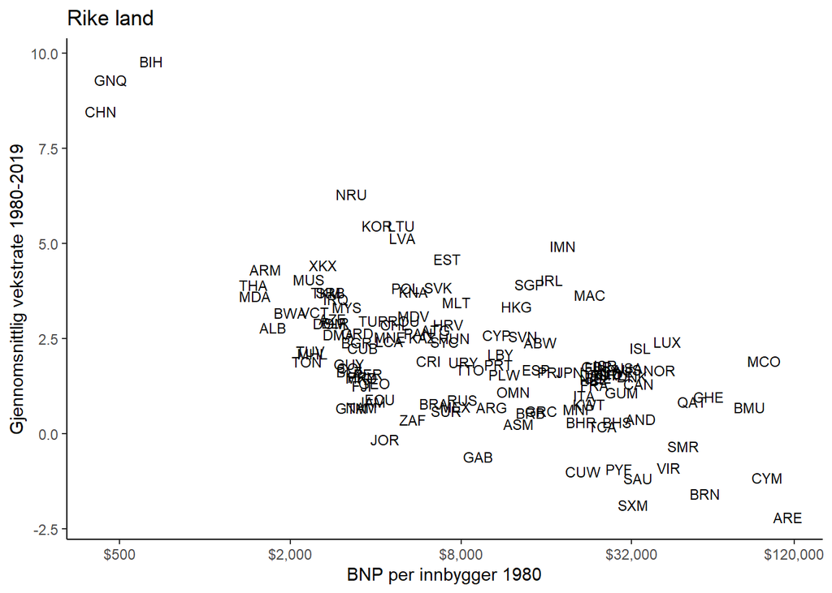

```r
plot1 <- ggplot(df_high_mid, aes(x = gdppc0 , y = avg_gdpgrowth, na.rm = TRUE)) +
  xlab("BNP per innbygger 1980") +
  ylab("Gjennomsnittlig vekstrate 1980-2019") +
  geom_text(aes(label=iso3c),size=3)+
  scale_x_continuous(labels = dollar)  + #
  theme(panel.grid.major = element_blank(), panel.grid.minor = element_blank(), panel.background = element_rect(fill = 'white'))+
  scale_x_continuous(trans = 'log2', labels = dollar, breaks=c(500, 2000, 8000, 32000, 120000)) +
  scale_y_continuous(breaks=c(-5, -2.5, 0, 2.5, 5, 7.5,10 ))+
  labs(title="Rike land")+
  theme_classic()
plot1
```

Stemmer prediksjonene fra Solowmodellen?

## Graf 2

Lag nå en graf der du har med alle land i datasetet.

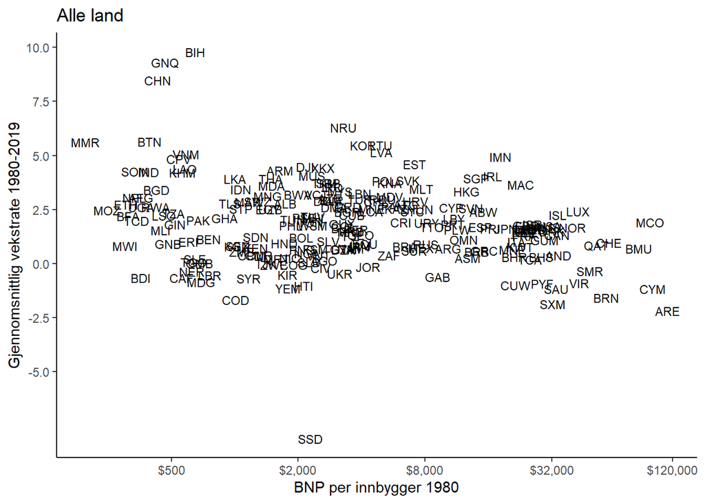

```r
plot1 <- ggplot(df_growth2019, aes(x = gdppc0 , y = avg_gdpgrowth, na.rm = TRUE)) +
  xlab("BNP per innbygger 1980") +
  ylab("Gjennomsnittlig vekstrate 1980-2019") +
  geom_text(aes(label=iso3c),size=3)+
  scale_x_continuous(labels = dollar)  +
  theme(panel.grid.major = element_blank(), panel.grid.minor = element_blank(), panel.background = element_rect(fill = 'white'))+
  scale_x_continuous(trans = 'log2', labels = dollar, breaks=c(500, 2000, 8000, 32000, 120000)) +
  scale_y_continuous(breaks=c(-5, -2.5, 0, 2.5, 5, 7.5,10 ))+
  labs(title="Alle land")+
  theme_classic()
plot1
```

Hva tenker du om prediksjonen fra Solowmodellen nå? Hva kan forklare det du ser?